# GHI 563 LabNote 2

Workplace Wellness Program Evaluation

Timothy Ojodare

February 12, 2026

# 1 Executive Summary

This analysis evaluates the “Thrive at Work” wellness program for **Meridian Health Systems** using machine learning techniques. We analyzed data from **1,000 employees** who completed a 12-week workplace wellness program.

# 2 Setup and Data Loading

## 2.1 Load Required Libraries

```r
# Load required packages
library(tidyverse)      # Data manipulation and visualization
library(caret)          # Machine learning framework
library(randomForest)   # Random Forest classifier
library(e1071)          # Support Vector Machines
library(pROC)           # ROC curve analysis (optional)
library(cluster)        # Clustering algorithms
library(factoextra)     # Clustering visualization
library(pheatmap)       # Heatmaps
library(knitr)          # Tables
library(kableExtra)     # Table formatting

# Set random seed for reproducibility
set.seed(42)
```

## 2.2 Load Data

```r
# Load the dataset
df <- read.csv('C:/Users/timothyo1/Downloads/workplace_wellness_data.csv')

# Display basic information
cat("Dataset Dimensions:", nrow(df), "rows x", ncol(df), "columns\n")
```

```
## Dataset Dimensions: 1000 rows x 18 columns
```

```r
cat("Total Employees:", nrow(df), "\n")
```

```
## Total Employees: 1000
```

```r
# Show first few rows
kable(head(df), caption = "First 6 rows of the dataset") %>%
  kable_styling(bootstrap_options = c("striped", "hover", "condensed"))
```

First 6 rows of the dataset

| employee_id | age | gender | department | years_employed | bmi | bp_systolic | resting_hr | baseline_activity_hrs | sleep_quality | stress_score | job_satisfaction | social_support | self_efficacy | sessions_attended | app_engagement | peer_challenge | program_success |
| --- | --- | --- | --- | --- | --- | --- | --- | --- | --- | --- | --- | --- | --- | --- | --- | --- | --- |
| EMP_0001 | 37 | Male | Sales | 8.0 | 21.4 | 123 | 67 | 1.3 | 2.5 | 9.8 | 6.0 | 8.5 | 6.3 | 7 | 27.4 | 0 | 1 |
| EMP_0002 | 28 | Male | Operations | 9.4 | 31.0 | 148 | 70 | 0.8 | 3.2 | 8.0 | 6.8 | 9.6 | 6.2 | 5 | 25.6 | 0 | 0 |
| EMP_0003 | 45 | Female | Administration | 7.1 | 24.6 | 149 | 58 | 0.4 | 8.8 | 6.5 | 4.6 | 9.9 | 4.4 | 7 | 28.5 | 0 | 1 |
| EMP_0004 | 41 | Female | Sales | 3.4 | 34.1 | 164 | 70 | 1.9 | 4.0 | 7.9 | 3.6 | 7.4 | 6.6 | 5 | 69.6 | 0 | 1 |
| EMP_0005 | 56 | Female | Manufacturing | 0.5 | 27.4 | 141 | 88 | 1.6 | 6.0 | 7.0 | 6.5 | 5.9 | 7.9 | 8 | 55.8 | 0 | 0 |
| EMP_0006 | 44 | Male | IT | 7.0 | 18.0 | 122 | 63 | 5.6 | 7.7 | 3.1 | 10.0 | 6.9 | 6.1 | 11 | 39.7 | 0 | 1 |

## 2.3 Data Overview

```r
# Summary statistics
summary(df[, c("age", "bmi", "stress_score", "sleep_quality",
               "app_engagement", "program_success")]) %>%
  kable(caption = "Summary Statistics for Key Variables") %>%
  kable_styling(bootstrap_options = c("striped", "hover"))
```

Summary Statistics for Key Variables

|  | age | bmi | stress_score | sleep_quality | app_engagement | program_success |
| --- | --- | --- | --- | --- | --- | --- |
|  | Min. :22.00 | Min. :18.00 | Min. : 1.000 | Min. : 2.000 | Min. : 0.50 | Min. :0.000 |
|  | 1st Qu.:35.75 | 1st Qu.:24.70 | 1st Qu.: 4.100 | 1st Qu.: 4.800 | 1st Qu.:24.30 | 1st Qu.:0.000 |
|  | Median :42.00 | Median :28.00 | Median : 5.700 | Median : 5.900 | Median :39.40 | Median :1.000 |
|  | Mean :42.28 | Mean :28.18 | Mean : 5.708 | Mean : 5.940 | Mean :41.99 | Mean :0.723 |
|  | 3rd Qu.:49.00 | 3rd Qu.:31.60 | 3rd Qu.: 7.200 | 3rd Qu.: 7.025 | 3rd Qu.:58.70 | 3rd Qu.:1.000 |
|  | Max. :65.00 | Max. :45.00 | Max. :10.000 | Max. :10.000 | Max. :97.90 | Max. :1.000 |

```r
# Check for missing values
missing_summary <- data.frame(
  Variable = names(df),
  Missing_Count = colSums(is.na(df)),
  Missing_Percent = round(colSums(is.na(df)) / nrow(df) * 100, 2)
)

kable(missing_summary, caption = "Missing Values Summary") %>%
  kable_styling(bootstrap_options = c("striped", "hover"))
```

Missing Values Summary

|  | Variable | Missing_Count | Missing_Percent |
| --- | --- | --- | --- |
| employee_id | employee_id | 0 | 0 |
| age | age | 0 | 0 |
| gender | gender | 0 | 0 |
| department | department | 0 | 0 |
| years_employed | years_employed | 0 | 0 |
| bmi | bmi | 0 | 0 |
| bp_systolic | bp_systolic | 0 | 0 |
| resting_hr | resting_hr | 0 | 0 |
| baseline_activity_hrs | baseline_activity_hrs | 0 | 0 |
| sleep_quality | sleep_quality | 0 | 0 |
| stress_score | stress_score | 0 | 0 |
| job_satisfaction | job_satisfaction | 0 | 0 |
| social_support | social_support | 0 | 0 |
| self_efficacy | self_efficacy | 0 | 0 |
| sessions_attended | sessions_attended | 0 | 0 |
| app_engagement | app_engagement | 0 | 0 |
| peer_challenge | peer_challenge | 0 | 0 |
| program_success | program_success | 0 | 0 |

## 2.4 Target Variable Distribution

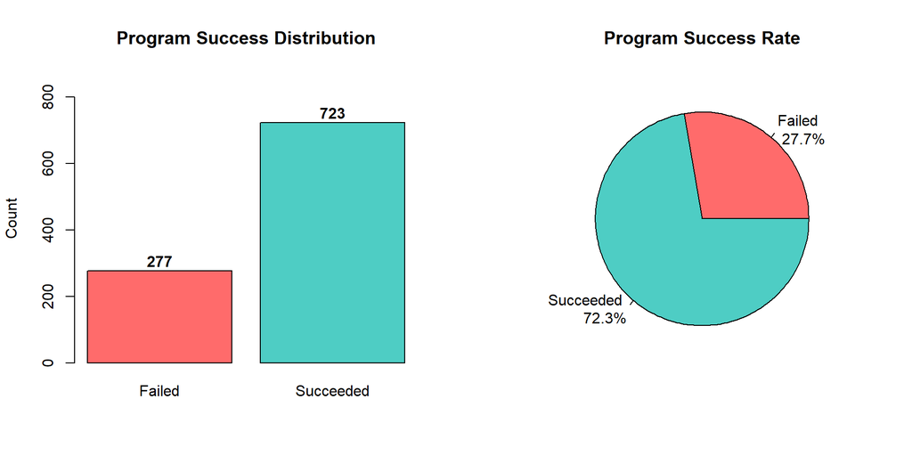

```r
# Create visualization of target variable
success_table <- table(df$program_success)
success_rate <- mean(df$program_success)

par(mfrow = c(1, 2))

# Bar plot
barplot(success_table,
        names.arg = c("Failed", "Succeeded"),
        col = c("#FF6B6B", "#4ECDC4"),
        main = "Program Success Distribution",
        ylab = "Count",
        ylim = c(0, max(success_table) * 1.2))
text(x = c(0.7, 1.9),
     y = success_table + 30,
     labels = success_table,
     font = 2)

# Pie chart
pie(success_table,
    labels = paste(c("Failed", "Succeeded"), "\n",
                   sprintf("%.1f%%", success_table/sum(success_table)*100)),
    col = c("#FF6B6B", "#4ECDC4"),
    main = "Program Success Rate")
```

```r
par(mfrow = c(1, 1))

cat("\n**Overall Success Rate:**", sprintf("%.2f%%", success_rate * 100))
```

```
##
## **Overall Success Rate:** 72.30%
```

# 3 Part 1: Classification Analysis

## 3.1 Objective

To build a predictive model to identify employees likely to succeed in the wellness program, enabling targeted resource allocation.

## 3.2 Data Preparation

```r
# Select features (exclude employee_id and target)
feature_cols <- setdiff(names(df), c('employee_id', 'program_success'))
X <- df[, feature_cols]
y <- factor(df$program_success, levels = c(0, 1), labels = c("No", "Yes"))

cat("Number of features:", length(feature_cols), "\n")
```

```
## Number of features: 16
```

```r
cat("Features:", paste(feature_cols, collapse = ", "), "\n")
```

```
## Features: age, gender, department, years_employed, bmi, bp_systolic, resting_hr, baseline_activity_hrs, sleep_quality, stress_score, job_satisfaction, social_support, self_efficacy, sessions_attended, app_engagement, peer_challenge
```

```r
# Convert categorical variables to factors
categorical_cols <- names(X)[sapply(X, is.character)]
cat("\nCategorical features:", paste(categorical_cols, collapse = ", "), "\n")
```

```
##
## Categorical features: gender, department
```

```r
for(col in categorical_cols) {
  X[[col]] <- as.factor(X[[col]])
}

# Create complete dataset
data_complete <- cbind(X, program_success = y)

# Train/test split (70-30)
train_index <- createDataPartition(y, p = 0.70, list = FALSE)
train_data <- data_complete[train_index, ]
test_data <- data_complete[-train_index, ]

cat("\nTraining set size:", nrow(train_data),
    sprintf("(%.1f%%)", nrow(train_data)/nrow(df)*100), "\n")
```

```
##
## Training set size: 701 (70.1%)
```

```r
cat("Test set size:", nrow(test_data),
    sprintf("(%.1f%%)", nrow(test_data)/nrow(df)*100), "\n")
```

```
## Test set size: 299 (29.9%)
```

## 3.3 Model 1: Random Forest

```r
# Train Random Forest model
rf_model <- randomForest(
  program_success ~ .,
  data = train_data,
  ntree = 100,
  mtry = 4,
  importance = TRUE,
  nodesize = 5
)

# Make predictions
y_pred_rf <- predict(rf_model, test_data)
y_pred_proba_rf <- predict(rf_model, test_data, type = "prob")[, "Yes"]

# Confusion matrix
cm_rf <- confusionMatrix(y_pred_rf, test_data$program_success, positive = "Yes")

print(cm_rf)
```

```
## Confusion Matrix and Statistics
##
##           Reference
## Prediction  No Yes
##        No   38   9
##        Yes  45 207
##
##                Accuracy : 0.8194
##                  95% CI : (0.771, 0.8613)
##     No Information Rate : 0.7224
##     P-Value [Acc > NIR] : 6.404e-05
##
##                   Kappa : 0.4803
##
##  Mcnemar's Test P-Value : 1.908e-06
##
##             Sensitivity : 0.9583
##             Specificity : 0.4578
##          Pos Pred Value : 0.8214
##          Neg Pred Value : 0.8085
##              Prevalence : 0.7224
##          Detection Rate : 0.6923
##    Detection Prevalence : 0.8428
##       Balanced Accuracy : 0.7081
##
##        'Positive' Class : Yes
##
```

### 3.3.1 Random Forest Performance Metrics

```r
# Extract metrics
rf_accuracy <- cm_rf$overall['Accuracy']
rf_precision <- cm_rf$byClass['Pos Pred Value']
rf_recall <- cm_rf$byClass['Sensitivity']
rf_f1 <- cm_rf$byClass['F1']

# Create summary table
rf_metrics_df <- data.frame(
  Metric = c("Accuracy", "Precision", "Recall", "F1-Score", "Specificity"),
  Score = c(rf_accuracy, rf_precision, rf_recall, rf_f1, cm_rf$byClass['Specificity'])
)

kable(rf_metrics_df, digits = 4, caption = "Random Forest Performance Metrics") %>%
  kable_styling(bootstrap_options = c("striped", "hover"), full_width = FALSE)
```

Random Forest Performance Metrics

|  | Metric | Score |
| --- | --- | --- |
| Accuracy | Accuracy | 0.8194 |
| Pos Pred Value | Precision | 0.8214 |
| Sensitivity | Recall | 0.9583 |
| F1 | F1-Score | 0.8846 |
| Specificity | Specificity | 0.4578 |

### 3.3.2 Feature Importance

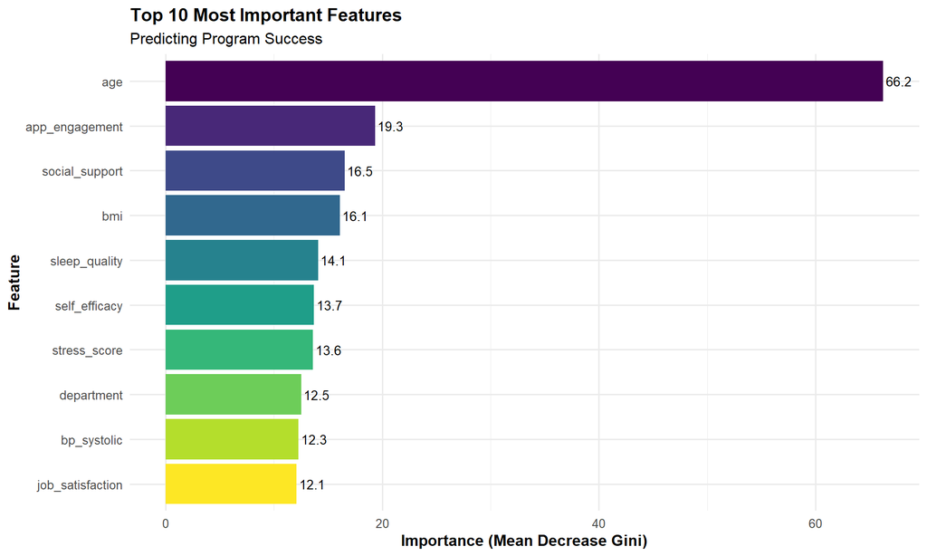

```r
# Get feature importance
importance_df <- data.frame(
  feature = rownames(importance(rf_model)),
  importance = importance(rf_model)[, "MeanDecreaseGini"]
) %>%
  arrange(desc(importance)) %>%
  head(10)

# Plot
ggplot(importance_df, aes(x = reorder(feature, importance), y = importance)) +
  geom_bar(stat = "identity", fill = viridis::viridis(10)) +
  coord_flip() +
  labs(
    title = "Top 10 Most Important Features",
    subtitle = "Predicting Program Success",
    x = "Feature",
    y = "Importance (Mean Decrease Gini)"
  ) +
  theme_minimal(base_size = 12) +
  theme(
    plot.title = element_text(face = "bold", size = 14),
    axis.title = element_text(face = "bold")
  ) +
  geom_text(aes(label = sprintf("%.1f", importance)),
            hjust = -0.1, size = 3.5)
```

```r
# Print table
kable(importance_df, digits = 2, caption = "Feature Importance Rankings") %>%
  kable_styling(bootstrap_options = c("striped", "hover"))
```

Feature Importance Rankings

|  | feature | importance |
| --- | --- | --- |
| age | age | 66.24 |
| app_engagement | app_engagement | 19.33 |
| social_support | social_support | 16.52 |
| bmi | bmi | 16.09 |
| sleep_quality | sleep_quality | 14.09 |
| self_efficacy | self_efficacy | 13.69 |
| stress_score | stress_score | 13.60 |
| department | department | 12.53 |
| bp_systolic | bp_systolic | 12.27 |
| job_satisfaction | job_satisfaction | 12.09 |

**Key Finding:** Age is the dominant predictor, accounting for much more importance than any other feature.

### 3.3.3 Confusion Matrix Visualization

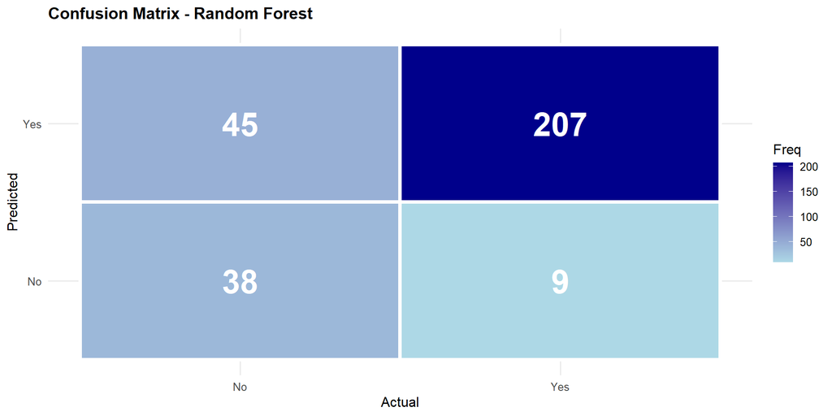

```r
# Create confusion matrix heatmap
cm_table <- as.data.frame(cm_rf$table)

ggplot(cm_table, aes(x = Reference, y = Prediction, fill = Freq)) +
  geom_tile(color = "white", size = 1.5) +
  geom_text(aes(label = Freq), size = 10, fontface = "bold", color = "white") +
  scale_fill_gradient(low = "lightblue", high = "darkblue") +
  labs(
    title = "Confusion Matrix - Random Forest",
    x = "Actual",
    y = "Predicted"
  ) +
  theme_minimal(base_size = 12) +
  theme(
    plot.title = element_text(face = "bold", size = 14),
    legend.position = "right"
  )
```

## 3.4 Model 2: Support Vector Machines

```r
# Prepare data for SVM (convert to numeric matrix)
X_train_svm <- model.matrix(program_success ~ . - 1, data = train_data)
X_test_svm <- model.matrix(program_success ~ . - 1, data = test_data)

# Scale features
preproc <- preProcess(X_train_svm, method = c("center", "scale"))
X_train_scaled <- predict(preproc, X_train_svm)
X_test_scaled <- predict(preproc, X_test_svm)

# SVM with Linear Kernel
svm_linear <- svm(X_train_scaled, train_data$program_success,
                  kernel = "linear", probability = TRUE)
y_pred_svm_linear <- predict(svm_linear, X_test_scaled)

cm_svm_linear <- confusionMatrix(y_pred_svm_linear, test_data$program_success, positive = "Yes")

# SVM with RBF Kernel
svm_rbf <- svm(X_train_scaled, train_data$program_success,
               kernel = "radial", probability = TRUE)
y_pred_svm_rbf <- predict(svm_rbf, X_test_scaled)

cm_svm_rbf <- confusionMatrix(y_pred_svm_rbf, test_data$program_success, positive = "Yes")

cat("SVM Linear Kernel - Accuracy:",
    sprintf("%.4f", cm_svm_linear$overall['Accuracy']), "\n")
```

```
## SVM Linear Kernel - Accuracy: 0.7224
```

```r
cat("SVM RBF Kernel - Accuracy:",
    sprintf("%.4f", cm_svm_rbf$overall['Accuracy']), "\n")
```

```
## SVM RBF Kernel - Accuracy: 0.7525
```

## 3.5 Model Comparison

```r
# Create comparison table
comparison_df <- data.frame(
  Model = c("Random Forest", "SVM (Linear)", "SVM (RBF)"),
  Accuracy = c(
    cm_rf$overall['Accuracy'],
    cm_svm_linear$overall['Accuracy'],
    cm_svm_rbf$overall['Accuracy']
  ),
  Precision = c(
    cm_rf$byClass['Pos Pred Value'],
    cm_svm_linear$byClass['Pos Pred Value'],
    cm_svm_rbf$byClass['Pos Pred Value']
  ),
  Recall = c(
    cm_rf$byClass['Sensitivity'],
    cm_svm_linear$byClass['Sensitivity'],
    cm_svm_rbf$byClass['Sensitivity']
  ),
  F1_Score = c(
    cm_rf$byClass['F1'],
    cm_svm_linear$byClass['F1'],
    cm_svm_rbf$byClass['F1']
  )
)

# Display table
kable(comparison_df, digits = 4,
      caption = "Classification Model Performance Comparison") %>%
  kable_styling(bootstrap_options = c("striped", "hover")) %>%
  row_spec(which.max(comparison_df$F1_Score), bold = TRUE, color = "white", background = "#4ECDC4")
```

Classification Model Performance Comparison

| Model | Accuracy | Precision | Recall | F1_Score |
| --- | --- | --- | --- | --- |
| Random Forest | 0.8194 | 0.8214 | 0.9583 | 0.8846 |
| SVM (Linear) | 0.7224 | 0.7224 | 1.0000 | 0.8388 |
| SVM (RBF) | 0.7525 | 0.7483 | 0.9907 | 0.8526 |

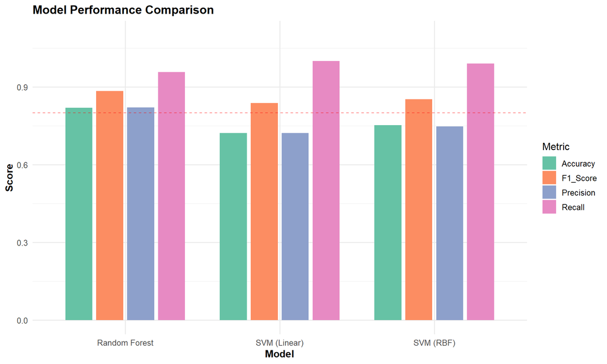

```r
# Visualize comparison
comparison_long <- comparison_df %>%
  pivot_longer(cols = -Model, names_to = "Metric", values_to = "Score")

ggplot(comparison_long, aes(x = Model, y = Score, fill = Metric)) +
  geom_bar(stat = "identity", position = position_dodge(width = 0.8), width = 0.7) +
  scale_fill_brewer(palette = "Set2") +
  labs(
    title = "Model Performance Comparison",
    y = "Score",
    fill = "Metric"
  ) +
  theme_minimal(base_size = 12) +
  theme(
    plot.title = element_text(face = "bold", size = 14),
    axis.title = element_text(face = "bold")
  ) +
  ylim(0, 1.1) +
  geom_hline(yintercept = 0.8, linetype = "dashed", color = "red", alpha = 0.5)
```

**Recommended Model:** **Random Forest** with F1-Score of 0.8846

# 4 Part 2: Clustering Analysis

## 4.1 Objective

Identify distinct employee profiles to design customized wellness program tracks.

## 4.2 Data Preparation for Clustering

```r
# Select clustering variables
clustering_vars <- c(
  'baseline_activity_hrs',
  'sleep_quality',
  'stress_score',
  'social_support',
  'self_efficacy',
  'app_engagement'
)

X_cluster <- df[, clustering_vars]

cat("Clustering variables:", paste(clustering_vars, collapse = ", "), "\n")
```

```
## Clustering variables: baseline_activity_hrs, sleep_quality, stress_score, social_support, self_efficacy, app_engagement
```

```r
cat("Number of observations:", nrow(X_cluster), "\n\n")
```

```
## Number of observations: 1000
```

```r
# Summary statistics
kable(summary(X_cluster),
      caption = "Summary Statistics - Clustering Variables") %>%
  kable_styling(bootstrap_options = c("striped", "hover"))
```

Summary Statistics - Clustering Variables

|  | baseline_activity_hrs | sleep_quality | stress_score | social_support | self_efficacy | app_engagement |
| --- | --- | --- | --- | --- | --- | --- |
|  | Min. : 0.000 | Min. : 2.000 | Min. : 1.000 | Min. : 1.000 | Min. : 1.500 | Min. : 0.50 |
|  | 1st Qu.: 0.600 | 1st Qu.: 4.800 | 1st Qu.: 4.100 | 1st Qu.: 4.800 | 1st Qu.: 5.100 | 1st Qu.:24.30 |
|  | Median : 1.500 | Median : 5.900 | Median : 5.700 | Median : 6.100 | Median : 6.100 | Median :39.40 |
|  | Mean : 2.375 | Mean : 5.940 | Mean : 5.708 | Mean : 6.055 | Mean : 6.162 | Mean :41.99 |
|  | 3rd Qu.: 3.300 | 3rd Qu.: 7.025 | 3rd Qu.: 7.200 | 3rd Qu.: 7.400 | 3rd Qu.: 7.200 | 3rd Qu.:58.70 |
|  | Max. :15.000 | Max. :10.000 | Max. :10.000 | Max. :10.000 | Max. :10.000 | Max. :97.90 |

```r
# Standardize features (z-score normalization)
X_cluster_scaled <- scale(X_cluster)
```

## 4.3 K-Means Clustering

```r
# Perform K-Means with K=3 and K=4
kmeans_3 <- kmeans(X_cluster_scaled, centers = 3, nstart = 25)
kmeans_4 <- kmeans(X_cluster_scaled, centers = 4, nstart = 25)

# Calculate silhouette scores
sil_k3 <- mean(silhouette(kmeans_3$cluster, dist(X_cluster_scaled))[, 3])
sil_k4 <- mean(silhouette(kmeans_4$cluster, dist(X_cluster_scaled))[, 3])

cat("K-Means (K=3) Silhouette Score:", sprintf("%.4f", sil_k3), "\n")
```

```
## K-Means (K=3) Silhouette Score: 0.1516
```

```r
cat("K-Means (K=4) Silhouette Score:", sprintf("%.4f", sil_k4), "\n")
```

```
## K-Means (K=4) Silhouette Score: 0.1447
```

## 4.4 K-Medoids (PAM) Clustering

```r
# Perform PAM clustering
pam_3 <- pam(X_cluster_scaled, k = 3)
pam_4 <- pam(X_cluster_scaled, k = 4)

cat("PAM (K=3) Silhouette Score:", sprintf("%.4f", pam_3$silinfo$avg.width), "\n")
```

```
## PAM (K=3) Silhouette Score: 0.1066
```

```r
cat("PAM (K=4) Silhouette Score:", sprintf("%.4f", pam_4$silinfo$avg.width), "\n")
```

```
## PAM (K=4) Silhouette Score: 0.1206
```

## 4.5 Clustering Method Comparison

```r
# Create comparison table
clustering_comparison <- data.frame(
  Method = c("K-Means (K=3)", "K-Means (K=4)", "PAM (K=3)", "PAM (K=4)"),
  Silhouette_Score = c(sil_k3, sil_k4, pam_3$silinfo$avg.width, pam_4$silinfo$avg.width)
)

kable(clustering_comparison, digits = 4,
      caption = "Clustering Performance Comparison") %>%
  kable_styling(bootstrap_options = c("striped", "hover")) %>%
  row_spec(which.max(clustering_comparison$Silhouette_Score),
           bold = TRUE, color = "white", background = "#4ECDC4")
```

Clustering Performance Comparison

| Method | Silhouette_Score |
| --- | --- |
| K-Means (K=3) | 0.1516 |
| K-Means (K=4) | 0.1447 |
| PAM (K=3) | 0.1066 |
| PAM (K=4) | 0.1206 |

```r
cat("\n**Note:** Higher Silhouette Score indicates better-defined clusters")
```

```
##
## **Note:** Higher Silhouette Score indicates better-defined clusters
```

**Recommended Clustering:** **K-Means with K=3** (Best Silhouette Score)

## 4.6 Cluster Visualization

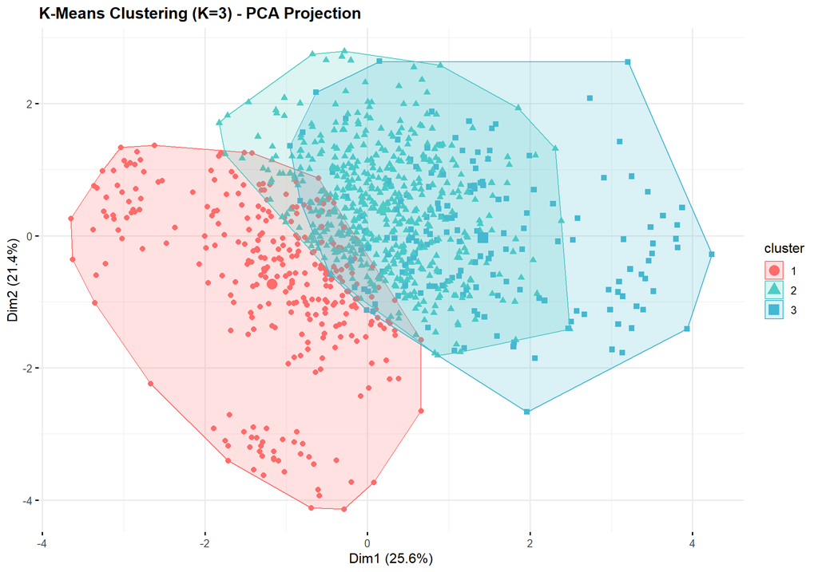

```r
# Use K=3 for detailed analysis
df$cluster <- kmeans_3$cluster

# PCA visualization
fviz_cluster(kmeans_3,
             data = X_cluster_scaled,
             palette = c("#FF6B6B", "#4ECDC4", "#45B7D1"),
             geom = "point",
             ellipse.type = "convex",
             pointsize = 2,
             ggtheme = theme_minimal(base_size = 12),
             main = "K-Means Clustering (K=3) - PCA Projection") +
  theme(plot.title = element_text(face = "bold", size = 14))
```

## 4.7 Silhouette Analysis

```
##   cluster size ave.sil.width
## 1       1  295          0.11
## 2       2  533          0.20
## 3       3  172          0.08
```

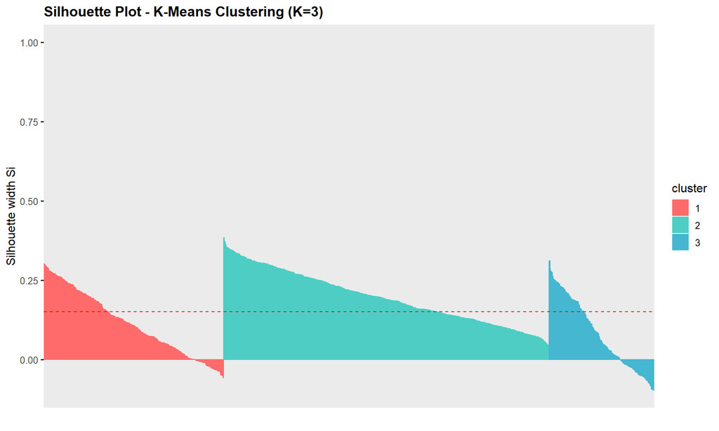

```r
# Silhouette plot
sil <- silhouette(kmeans_3$cluster, dist(X_cluster_scaled))

fviz_silhouette(sil,
                palette = c("#FF6B6B", "#4ECDC4", "#45B7D1"),
                ggtheme = theme_minimal(base_size = 12)) +
  labs(title = "Silhouette Plot - K-Means Clustering (K=3)") +
  theme(plot.title = element_text(face = "bold", size = 14))
```

## 4.8 Cluster Profiles

```r
# Calculate cluster means
cluster_profiles <- df %>%
  group_by(cluster) %>%
  summarise(
    Size = n(),
    Avg_Activity = mean(baseline_activity_hrs),
    Avg_Sleep = mean(sleep_quality),
    Avg_Stress = mean(stress_score),
    Avg_Support = mean(social_support),
    Avg_Efficacy = mean(self_efficacy),
    Avg_Engagement = mean(app_engagement),
    Success_Rate = mean(program_success)
  )

kable(cluster_profiles, digits = 2,
      caption = "Detailed Cluster Profiles") %>%
  kable_styling(bootstrap_options = c("striped", "hover"))
```

Detailed Cluster Profiles

| cluster | Size | Avg_Activity | Avg_Sleep | Avg_Stress | Avg_Support | Avg_Efficacy | Avg_Engagement | Success_Rate |
| --- | --- | --- | --- | --- | --- | --- | --- | --- |
| 1 | 295 | 1.68 | 4.69 | 7.54 | 6.95 | 6.88 | 51.06 | 0.75 |
| 2 | 533 | 1.48 | 6.34 | 5.01 | 5.92 | 5.73 | 34.73 | 0.71 |
| 3 | 172 | 6.35 | 6.84 | 4.74 | 4.95 | 6.27 | 48.91 | 0.74 |

### 4.8.1 Cluster Characteristics Heatmap

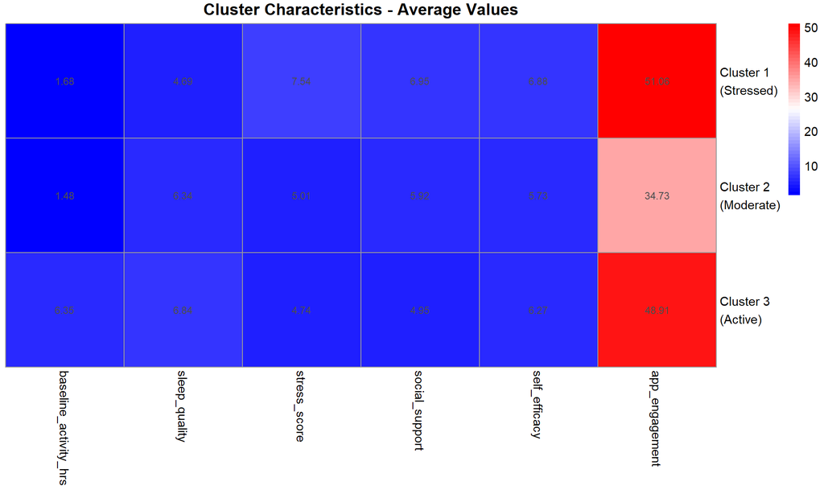

```r
# Prepare data for heatmap
cluster_means <- df %>%
  group_by(cluster) %>%
  summarise(across(all_of(clustering_vars), mean)) %>%
  column_to_rownames("cluster")

rownames(cluster_means) <- c("Cluster 1\n(Stressed)",
                              "Cluster 2\n(Moderate)",
                              "Cluster 3\n(Active)")

pheatmap(cluster_means,
         display_numbers = TRUE,
         number_format = "%.2f",
         cluster_rows = FALSE,
         cluster_cols = FALSE,
         color = colorRampPalette(c("blue", "white", "red"))(50),
         main = "Cluster Characteristics - Average Values",
         fontsize = 11)
```

### 4.8.2 Cluster Distribution

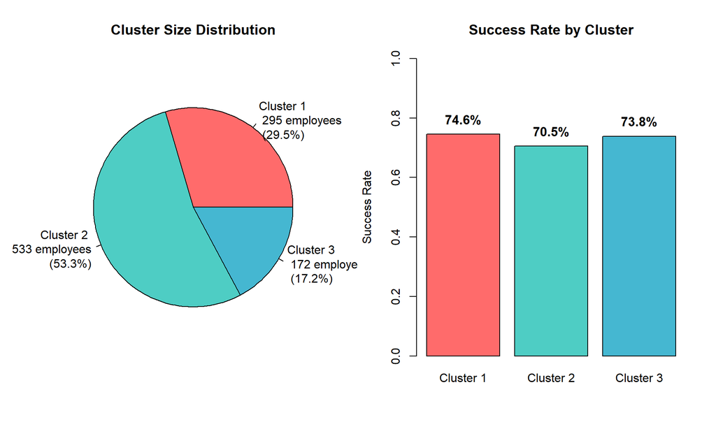

```r
# Cluster sizes and success rates
par(mfrow = c(1, 2))

# Pie chart - sizes
cluster_counts <- table(df$cluster)
pie(cluster_counts,
    labels = paste("Cluster", names(cluster_counts), "\n",
                   cluster_counts, "employees\n",
                   sprintf("(%.1f%%)", cluster_counts/sum(cluster_counts)*100)),
    col = c("#FF6B6B", "#4ECDC4", "#45B7D1"),
    main = "Cluster Size Distribution",
    cex.main = 1.2)

# Bar chart - success rates
success_rates <- tapply(df$program_success, df$cluster, mean)
barplot(success_rates,
        names.arg = paste("Cluster", 1:3),
        col = c("#FF6B6B", "#4ECDC4", "#45B7D1"),
        ylim = c(0, 1),
        main = "Success Rate by Cluster",
        ylab = "Success Rate",
        cex.main = 1.2)
text(x = seq(0.7, by = 1.2, length.out = 3),
     y = success_rates + 0.05,
     labels = sprintf("%.1f%%", success_rates * 100),
     cex = 1.1, font = 2)
```

```r
par(mfrow = c(1, 1))
```

# 5 Cluster Interpretations

## 5.1 Cluster 1: Stressed & Sleep-Deprived Professionals

**Size:** 295 employees (29.5%)

**Characteristics:** - Sleep Quality: 4.7/10 (↓↓ well below average) - Stress Score: 7.5/10 (↑ above average) - Social Support: 6.9/10 (↑ strong) - App Engagement: 51.1/100

**Success Rate:** 74.6%

**Recommended Interventions:** - Stress management workshops - Sleep hygiene education - Mindfulness training - Flexible coaching schedules

## 5.2 Cluster 2: Moderately Engaged Majority

**Size:** 533 employees (53.3%)

**Characteristics:** - All metrics near average - Largest segment - Standard wellness program participants

**Success Rate:** 70.5%

**Recommended Interventions:** - Standard wellness coaching - Gamification strategies - Social challenges - Accessible fitness options

## 5.3 Cluster 3: Active & Autonomous Achievers

**Size:** 172 employees (17.2%)

**Characteristics:** - Baseline Activity: 6.4 hrs/week (↑↑ high) - App Engagement: 48.9/100 (↑↑ high) - Self-motivated and already active

**Success Rate:** 73.8%

**Recommended Interventions:** - Advanced fitness challenges - Peer mentorship roles - Self-directed programs - Recognition systems

# 6 Conclusions and Recommendations

## 6.2 Actionable Recommendations

### 6.2.1 For Future Enrollment

1. **Age-based outreach** - Design different materials for <35, 35-50, >50 age groups
2. **Pre-program screening** - Use Random Forest model to identify at-risk employees
3. **App engagement training** - Mandatory onboarding for predicted low-engagers

### 6.2.2 For Program Design

**Implement 3-Track System:**

| Track | Target | Focus |
| --- | --- | --- |
| Stress Relief | Cluster 1 (30%) | Sleep hygiene, stress management |
| Standard Wellness | Cluster 2 (53%) | Coaching, gamification, social challenges |
| Performance | Cluster 3 (17%) | Advanced goals, mentorship |

## 6.3 Limitations

1. Sample size of 1,000 may not capture full variation
2. 12-week duration may differ from longer programs
3. Self-reported data subject to bias
4. Missing dietary and health history data

## 6.4 Future Work

1. **Longitudinal tracking** - Monitor cluster migration across cycles
2. **Cost-benefit analysis** - Calculate ROI per intervention track
3. **External validation** - Test models on new cohorts
4. **Causal inference** - Use propensity score matching

# 8 Appendix: Complete Code

All code used in this analysis is available in the following files:

- `wellness_analysis.R` - Main analysis script
- `create_visualizations_FIXED.R` - Visualization script

**Data File:** `workplace_wellness_data.csv`

**Report Generated:** 2026-02-12 00:40:43.802806